# Big Mart Sales Data Analysis, Visualization, Modelling

### Next we’ll perform some feature engineering - merging and/or modifying variables where it seems appropriate.

**Outlet Type Combinations?**  
First we’ll take a look at the ‘Outlet_Type’ variable, in particular, whether Supermarket Type2 and Supermarket Type3 ought to be combined into one category.

```r
#Print out the mean sales grouped by Outlet_Type
data %>%
        group_by(Outlet_Type) %>%
        summarise(mean_sales = mean(Item_Outlet_Sales, na.rm = TRUE))
```

```
## # A tibble: 4 x 2
##   Outlet_Type       mean_sales
##   <chr>                  <dbl>
## 1 Grocery Store           340.
## 2 Supermarket Type1      2316.
## 3 Supermarket Type2      1995.
## 4 Supermarket Type3      3694.
```

The mean sales prove to be significantly different for Supermarket Type2 and Type3 (in fact there’s not a bad spread overall), so we won’t merge these categories. Merging two categories which could potentially be impacting our output variable could confound our analysis.

**Item Visibility**  
Second, we’ll get back to the issue of ‘Item_Visibility’, which had the mysterious minimun of zero.  
The zero values are most likely just missing information, so we’ll impute Item_Visibility based on the given item’s (Item_Identifier’s) mean visibility.

```r
#Group by the item ID and replace zero values in Item_Visibility with the corresponding item's average visibility across all stores
data <- data %>%
        group_by(Item_Identifier) %>%
        mutate(Item_Visibility = replace(Item_Visibility, Item_Visibility == 0, mean(Item_Visibility)))
summary(data$Item_Visibility)
```

```
##     Min.  1st Qu.   Median     Mean  3rd Qu.     Max.
## 0.003575 0.031150 0.057190 0.069710 0.096930 0.328400
```

Now we have absolute visibility stats for all products in all stores, but in order to determine how a particular product’s visibility at a given location impacts its sales at that location, we need to know how the product’s visibility at that particular location compares with the product’s visibility at other locations.  
To understand this, we’ll need to create a new metric, namely, the ratio of the product’s visibility at a given store to its mean visibility across all stores.

```r
#Calculate the new variable, 'Item_Visibility_MeanRatio'
data <- data %>%
        group_by(Item_Identifier) %>%
        mutate(Item_Mean_Visibility = mean(Item_Visibility)) %>%
        mutate(Item_Visibility_MeanRatio = Item_Visibility / Item_Mean_Visibility) %>%
        select(-Item_Mean_Visibility)
```

**Item Type Recategorization**

Here let’s take a look at mean sales by Item_Type to see if there’s any worthwhile rearranging we can do

```r
data %>%
        group_by(Item_Type) %>%
        summarise(mean_by_type = mean(Item_Outlet_Sales, na.rm=TRUE)) %>%
        arrange(desc(mean_by_type))
```

```
## # A tibble: 16 x 2
##    Item_Type             mean_by_type
##    <chr>                        <dbl>
##  1 Starchy Foods                2374.
##  2 Seafood                      2326.
##  3 Fruits and Vegetables        2289.
##  4 Snack Foods                  2277.
##  5 Household                    2259.
##  6 Dairy                        2233.
##  7 Canned                       2225.
##  8 Breads                       2204.
##  9 Meat                         2159.
## 10 Hard Drinks                  2139.
## 11 Frozen Foods                 2133.
## 12 Breakfast                    2112.
## 13 Health and Hygiene           2010.
## 14 Soft Drinks                  2007.
## 15 Baking Goods                 1953.
## 16 Others                       1926.
```

I’m curious to see what the ‘Others’ category looks like

```r
data %>%
        filter(Item_Type == 'Others') %>%
        do(head(.))
```

```
## # A tibble: 180 x 14
## # Groups:   Item_Identifier [30]
##    Item_Identifier Item_Weight Item_Fat_Content Item_Visibility Item_Type
##    <chr>                 <dbl> <chr>                      <dbl> <chr>
##  1 NCI31                  20.0 Low Fat                   0.0817 Others
##  2 NCI31                  20.0 Low Fat                   0.0815 Others
##  3 NCI31                  20.0 low fat                   0.136  Others
##  4 NCI31                  20.0 Low Fat                   0.0815 Others
##  5 NCI31                  12.6 Low Fat                   0.0809 Others
##  6 NCI31                  20.0 Low Fat                   0.0813 Others
##  7 NCJ19                  18.6 LF                        0.118  Others
##  8 NCJ19                  18.6 Low Fat                   0.118  Others
##  9 NCJ19                  18.6 Low Fat                   0.198  Others
## 10 NCJ19                  12.6 Low Fat                   0.118  Others
## # ... with 170 more rows, and 9 more variables: Item_MRP <dbl>,
## #   Outlet_Identifier <chr>, Outlet_Establishment_Year <int>,
## #   Outlet_Size <chr>, Outlet_Location_Type <chr>, Outlet_Type <chr>,
## #   Item_Outlet_Sales <dbl>, source <chr>, Item_Visibility_MeanRatio <dbl>
```

Actually by going through all 180 entries, it is clear that all ‘Others’ items are some form of non-consumable (marked with NC in the ‘Item_Identifier column). I also just noticed that NCs also have an Item_Fat_Content entry, namely ’Low Fat’.. We’ll probably change this later.  
Let’s find out what Item_Types are included in the non-consumables category

```r
data %>%
        filter(grepl('NC', Item_Identifier)) %>%
        group_by(Item_Type) %>%
        distinct(Item_Type)
```

```
## # A tibble: 3 x 1
## # Groups:   Item_Type [3]
##   Item_Type
##   <chr>
## 1 Household
## 2 Health and Hygiene
## 3 Others
```

Only these 3 Item_Types in unconsumables. It may make sense to combined Others with Health and Hygiene, but the Household type mean sales is considerably higher than the other two.

As such maybe there’s a better way to group Item_Types than by ID code. (In addition to NC=‘non-consumables’, there is FD=‘foods’ and DR=‘drinks’, but it doesn’t immediately seem to make sense to combine item types in to these three categories).

In fact, let’s combine item types by utility/necessity, which seems to me like it may be more correlated with sales than whether the item happens to be food or not. Consumers will be looking to purchase some of all three ID categories (food, beverage, and non-consumable) in order to sustain their livelihood. Is there not some form of decreasing marginal returns to consumer surplus when filling your shopping cart with food vs. beverage vs. household goods, etc.? Won’t you get more benefit from the first unit of laundry detergent than the 400th potato?

SO, that said let’s group the item types as best we can by their average sales and a judgement of necessity.

Looking at the mean_by_type column for the 16 item types above, let’s see if we can’t create groups based on the mean sales, and how likely the AVERAGE consumer may be to buy from a certain group.

What first catches my eye is the top selling item types, from ‘Starchy Foods’ down to ‘Breads’. Once you get into the ‘Meat’ and ‘Hard Drinks’ categories, you may be cutting out a larger portion of consumers who won’t be purchasing these items, or at least not as regularly as, say, ‘Fruits and Vegetables’.  
From ‘Meats’ down to ‘Breakfast’ seems to make a nice 2nd category. After ‘Breakfast’, average sales drop by over 100, and we get categories that you’d maybe just purchase in smaller quantities when you run out of supplies(namely ‘Health and Hygiene’ and ‘Baking Goods’), or maybe on special occasions (for ‘Soft Drinks’).

Note: The top two categories, ‘Starchy Foods’ and ‘Seafood’ also stand out to me, but ‘Starchy Foods’ just seems to me a really vague way to categorize (like, aren’t ‘breads’ starchy as well?), and we don’t have enough information with this dataset to know exactly what’s in there (though I imagine it would be pastas, rice, etc.). That said I’m hesitant to put it in one category alone with ‘Seafood’. Seafood tends to be expensive in the U.S., so it makes sense that mean sales would be relatively high, but ‘Starchy Foods’ is probably leading sales due to the quantity that customers by. These are completely different products with high sales for different reasons, so I won’t create a new category on the basis of sale numbers just for these two.

OK, so let’s go ahead and label these 3 groups in a new column

```r
#Add item types to variables representing our new categories
sales_high <- c('Starchy Foods', 'Seafood', 'Fruits and Vegetables', 'Snack Foods', 'Household', 'Dairy', 'Canned', 'Breads')
sales_med <- c('Meat', 'Hard Drinks', 'Frozen Foods', 'Breakfast')

#Create the categories 'High Sales', 'Medium Sales', and 'Low Sales' in new column, 'Item_Type_Aggregate'
data <- data %>%
        group_by() %>%
        mutate(Item_Type_Aggregate = ifelse(data$Item_Type %in% sales_high, 'High Sales', ifelse(data$Item_Type %in% sales_med, 'Medium Sales', 'Low Sales')))
data %>%
        group_by(Item_Type_Aggregate) %>%
        distinct(Item_Type_Aggregate)
```

```
## # A tibble: 3 x 1
## # Groups:   Item_Type_Aggregate [3]
##   Item_Type_Aggregate
##   <chr>
## 1 High Sales
## 2 Low Sales
## 3 Medium Sales
```

**Outlet Establishment Year**  
Next we come to a variable we can definitely improve on for our analysis: ‘Outlet_Establishment_Year’.  
We’re going to create a new variable, ‘Outlet_Years’, to more intuitively represent location age.

```r
#Subtract year established from 2013, as 2013 is the year in which this sales data was collected
data  <- data %>%
        mutate(Outlet_Years = 2013 - Outlet_Establishment_Year)
summary(data$Outlet_Years)
```

```
##    Min. 1st Qu.  Median    Mean 3rd Qu.    Max.
##    4.00    9.00   14.00   15.17   26.00   28.00
```

**Item Fat Content**  
Next we’ll deal with the mislabelling of the Item_Fat_Content categories

```r
#Just a reminder of what the existing category names are
data %>%
        group_by(Item_Fat_Content) %>%
        distinct(Item_Fat_Content)
```

```
## # A tibble: 5 x 1
## # Groups:   Item_Fat_Content [5]
##   Item_Fat_Content
##   <chr>
## 1 Low Fat
## 2 Regular
## 3 low fat
## 4 LF
## 5 reg
```

```r
#Replace redundant category names with 'Low Fat' and 'Regular' for the sake of consistency
data$Item_Fat_Content <- recode(data$Item_Fat_Content,
                                LF = 'Low Fat',
                                `low fat` = 'Low Fat',
                                reg = 'Regular')

#And we musn't forget to change the fat content label for non-consumable items
data <- data %>%
        mutate(Item_Fat_Content = replace(Item_Fat_Content, grepl('NC', Item_Identifier), 'Non-Consumable'))
#Check to make sure we have just the two categories remaining
data %>% group_by(Item_Fat_Content) %>% select(Item_Fat_Content) %>% apply(2, table)
```

```
##                Item_Fat_Content
## Low Fat                    6499
## Non-Consumable             2686
## Regular                    5019
```

### Before constructing a model with our tidied and modified data, let’s do some visualizaiton of the relationships between individual attributes and overall sales

**Sales on Item_MRP**

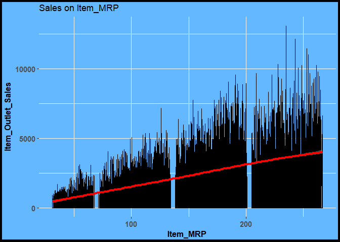

```r
#Simply Item_Outlet_Sales on Item_MRP
ggplot(data, aes(x = Item_MRP, y = Item_Outlet_Sales)) +
        geom_density(stat = 'identity') +
        geom_smooth(color = 'red', size = 1.5) +
        ggtitle('Sales on Item_MRP') +
        bigmart_theme
```

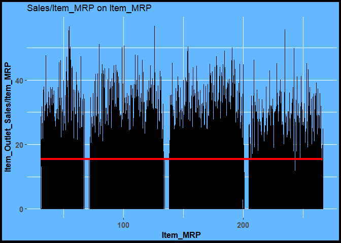

```r
#And dividing sales by the price to adjust for the fact that sales is basically price * quantity
ggplot(data, aes(x = Item_MRP, y = Item_Outlet_Sales / Item_MRP)) +
        geom_density(stat = 'identity') +
        geom_smooth(color = 'red', size = 1.5) +
        ggtitle('Sales/Item_MRP on Item_MRP') +
        bigmart_theme
```

As anticipated, the correlation between price and sales comes from the way in which Item_Outlet_Sales is calculated to begin with

To see visualizations for a wider range of attributes against Item_Outlet_Sales, check out my Shiny app:  
https://warriwes.shinyapps.io/BigmartSales_Viz/

#### Below are just a few highlights and my comments:

**Sales on Item_Visibility_MeanRatio**

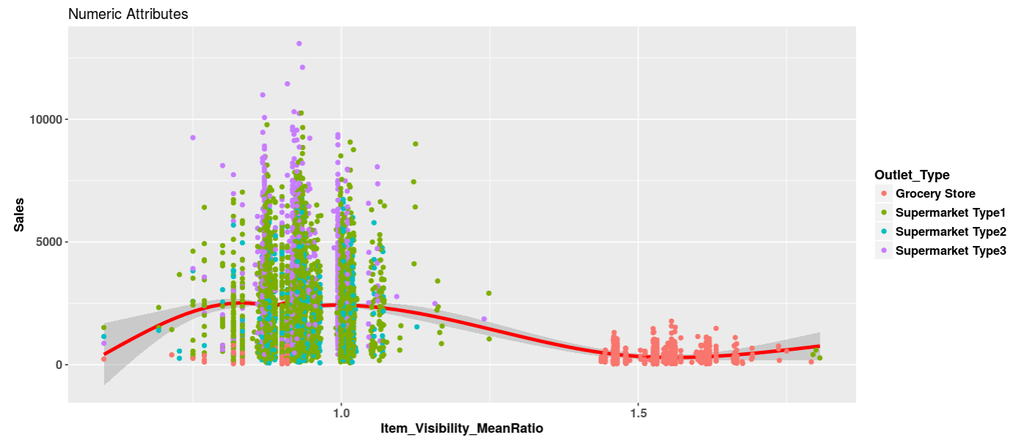

We can see here that the item visibility distribution is pulled way out by products in grocery stores. What this tells us is that grocery stores in fact have much less inventory, and therefore the ‘visibility’ awarded to each individual item is automatically greater than it would be in a supermarket

**Sales on Item_Weight**

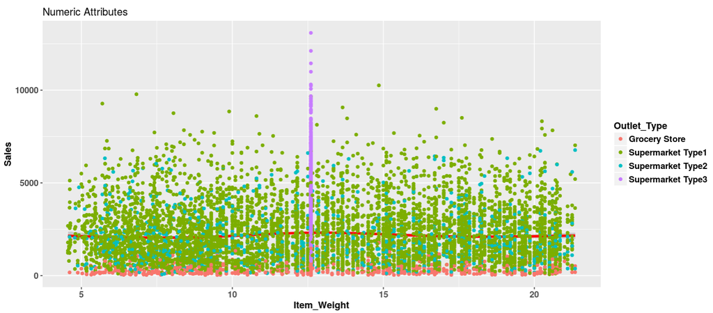

**Sales on Item_Type_Aggregate**

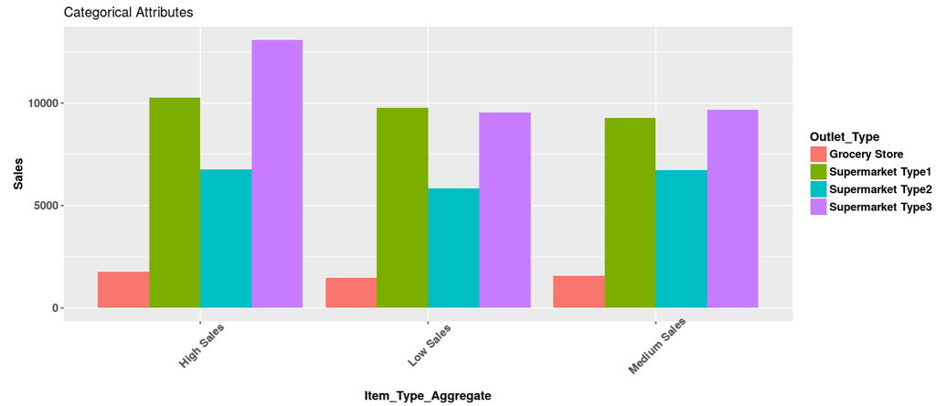

Just using sales vs. our modified item types for a clear picture, we can see that all-in-all, outlet type has a major effect on sales. Interestingly, Type 1 supermarkets surpass Type 2 supermarkets overwhelmingly, but even more clear is the gap between grocery stores and all supermarket types.

**Preparing data for model development and testing**  
Prepare to split back into train and test sets

```r
#Drop columns we replaced
data <- data %>%
        select(-c(Item_Type, Outlet_Establishment_Year))
#Set item and outlet ID pairs to row names and coerce character columns into factors (by converting data to data.frame)
ID_cols <- paste(data$Item_Identifier, data$Outlet_Identifier)
data_df <- as.data.frame(unclass(data), row.names = ID_cols)
#Split back into train and test on 'source' column
train <- data_df %>%
        filter(source == 'train')
test <- data_df %>%
        filter(source == 'test')
#Drop unnecessary columns
train <- train %>%
        select(-source)
test <- test %>%
        select(-c(source, Item_Outlet_Sales))
```

Export prepared train/test sets to csv files

```r
write_csv(train, 'train_new.csv')
write_csv(test, 'test_new.csv')
```

```r
train_1 <- train %>%
        select(-c(Item_Identifier, Outlet_Identifier))
```

**Random Forest Model**

Now it’s time to test out our model..

```r
library(randomForest)
```

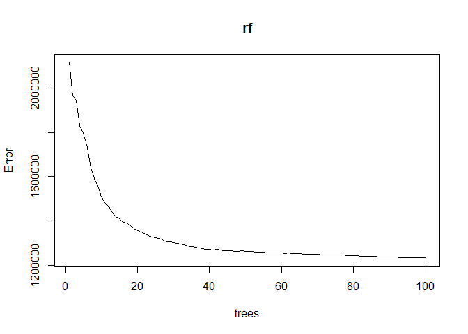

```r
rf <- randomForest(Item_Outlet_Sales ~ ., ntree = 100, data = train_1)
plot(rf)
```

```r
print(rf)
```

```
##
## Call:
##  randomForest(formula = Item_Outlet_Sales ~ ., data = train_1,      ntree = 100)
##                Type of random forest: regression
##                      Number of trees: 100
## No. of variables tried at each split: 3
##
##           Mean of squared residuals: 1232897
##                     % Var explained: 57.66
```

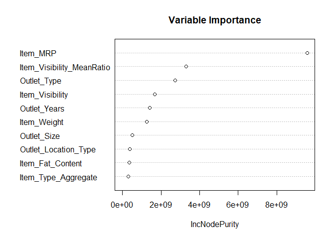

```r
varImpPlot(rf, sort = T, n.var = 10,
           main = 'Variable Importance')
```

#### Just another way to visualize the results:

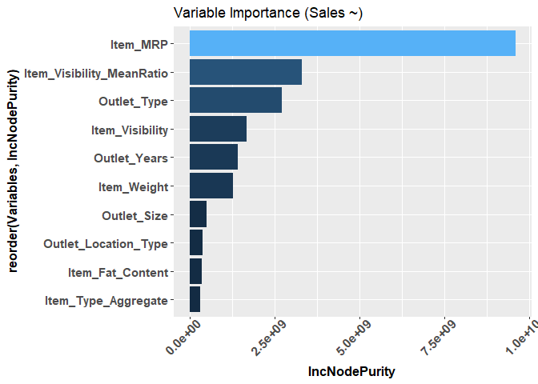

```r
#Create variable importance data.frame
var_imp = data.frame(importance(rf, type=2))

#Add row names columns
var_imp$Variables = row.names(var_imp)
var_imp <- var_imp[order(var_imp$IncNodePurity, decreasing = T),]

#Plot bar graph showing variable importance
ggplot(var_imp, aes(x = reorder(Variables, IncNodePurity), y = IncNodePurity, fill = IncNodePurity)) +
        geom_col() +
        theme(
                axis.text.x = element_text(angle = 45, hjust = 0.85),
                legend.position = 'none'
                ) +
        bold_theme +
        ggtitle('Variable Importance (Sales ~)') +
        coord_flip()
```

Making it clear how biased the model is toward Item_MRP

#### Let’s say we just model against quantities of items sold (Sales / MRP)…

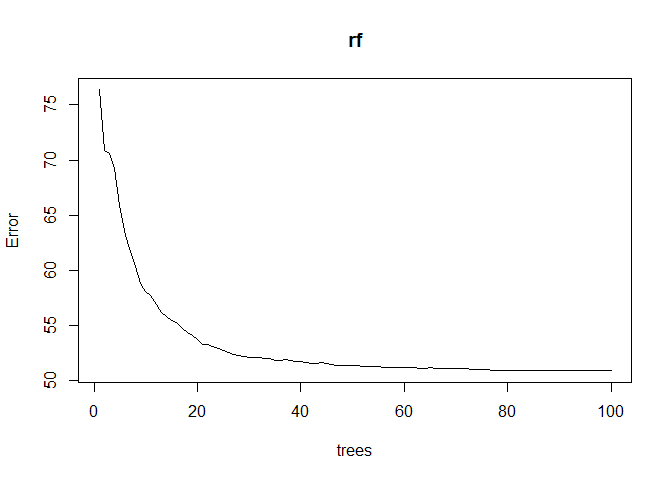

```r
library(randomForest)
rf <- randomForest(Item_Outlet_Sales / Item_MRP ~ ., ntree = 100, data = train_1)
plot(rf)
```

```r
print(rf)
```

```
##
## Call:
##  randomForest(formula = Item_Outlet_Sales/Item_MRP ~ ., data = train_1,      ntree = 100)
##                Type of random forest: regression
##                      Number of trees: 100
## No. of variables tried at each split: 3
##
##           Mean of squared residuals: 50.92052
##                     % Var explained: 39.74
```

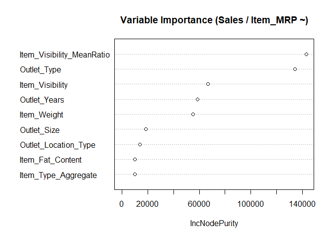

```r
varImpPlot(rf, sort = T, n.var = 9,
           main = 'Variable Importance (Sales / Item_MRP ~)')
```

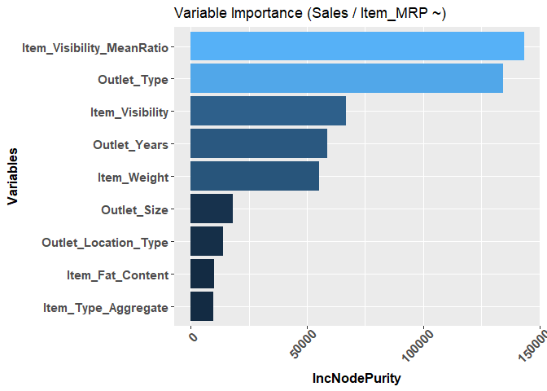

```r
#Create variable importance data.frame
var_imp = data.frame(importance(rf, type=2))

#Add row names columns
var_imp$Variables = row.names(var_imp)
var_imp <- var_imp[order(var_imp$IncNodePurity, decreasing = T),]

#Plot bar graph showing variable importance
ggplot(var_imp, aes(x = reorder(Variables, IncNodePurity), y = IncNodePurity, fill = IncNodePurity)) +
        geom_col() +
        theme(
                axis.text.x = element_text(angle = 45, hjust = 0.85),
                legend.position = 'none'
                ) +
        bold_theme +
        ggtitle('Variable Importance (Sales / Item_MRP ~)') +
        xlab('Variables') +
        coord_flip()
```

Removing Item_MRP gives us a clearer picture of how the other attributes influence the *quantity* of a given item that is sold